# Analysis of Chance of Admission

#### Another boxplot

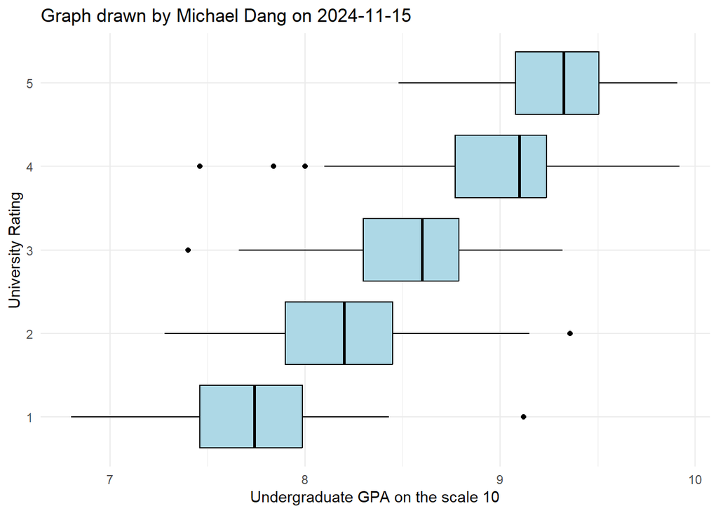

```r
dataset |>
  ggplot(aes(x = as.factor(university_rating), y = cgpa)) +
    geom_boxplot(fill = "lightblue", color = "black") +
    ggtitle("Graph drawn by Michael Dang on 2024-11-15") +
    xlab("University Rating") +
    ylab("Undergraduate GPA on the scale 10") +
    coord_flip() +
    theme_minimal()
```

## Histogram plot

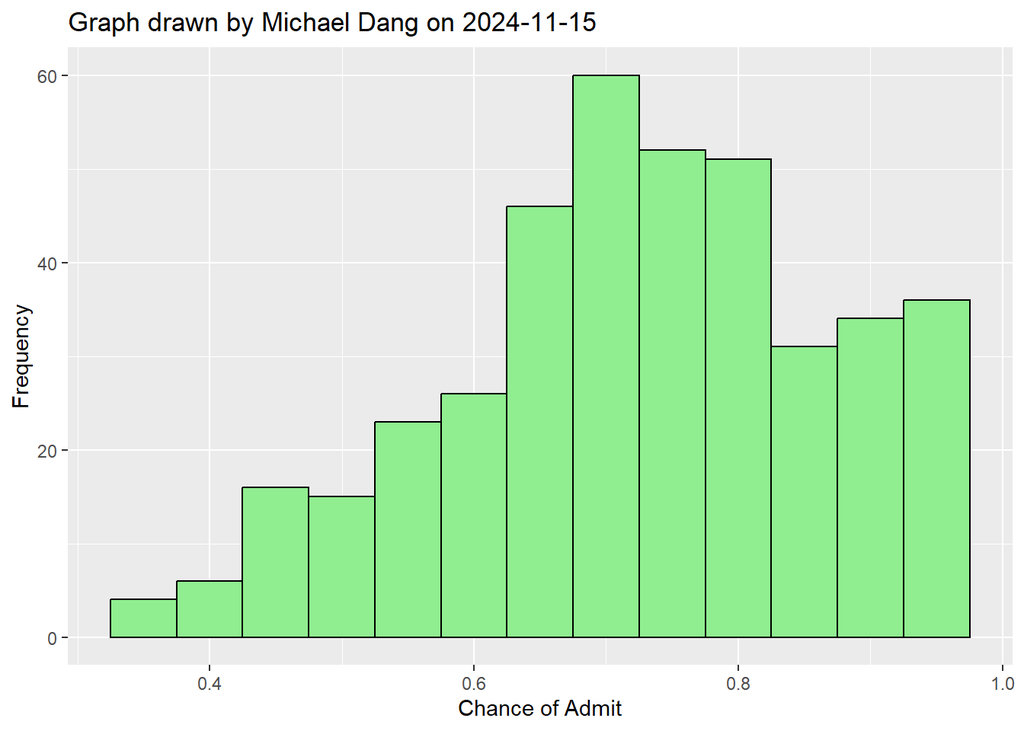

```r
dataset |>
  ggplot(aes(x = chance_of_admit)) +
    geom_histogram(binwidth = 0.05, fill = "lightgreen", color = "black") +
    ggtitle("Graph drawn by Michael Dang on 2024-11-15") +
    xlab("Chance of Admit") +
    ylab("Frequency")
```

#### Another histogram plot

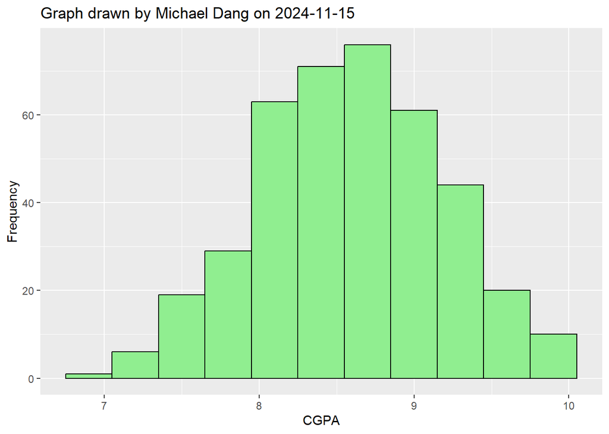

```r
dataset |>
  ggplot(aes(x = cgpa)) +
    geom_histogram(binwidth = 0.3, fill = "lightgreen", color = "black") +
    ggtitle("Graph drawn by Michael Dang on 2024-11-15") +
    xlab("CGPA") +
    ylab("Frequency")
```

The histogram of CGPA shows roughly bell-shaped distribution, which suggests it may approximate a normal distribution.

## Hypothesis test

- Null hypothesis ($H_0$): The mean “Chance of Admit” is the same across all university ratings.
- Alternative hypothesis ($H_a$): The mean “Chance of Admit” differs for at least one university rating group.
- $H_0: \mu = \mu_0$ vs $H_a: \mu \neq \mu_0$

## One-way ANOVA

```r
m1 <- aov(chance_of_admit ~ as.factor(university_rating), data = dataset)
tidy(m1)
```

```
# A tibble: 2 × 6
  term                            df sumsq meansq statistic   p.value
  <chr>                        <dbl> <dbl>  <dbl>     <dbl>     <dbl>
1 as.factor(university_rating)     4  4.12 1.03        102.  1.31e-59
2 Residuals                      395  3.99 0.0101       NA  NA
```

The F-ratio is large and the p-value is small. Conclude there is a differs for at least one university rating group.

Since ANOVA indicates significant differences, perform post-hoc tests (e.g., Tukey’s HSD) to identify which specific groups (university ratings) differ from each other.

```r
TukeyHSD(m1)
```

```
  Tukey multiple comparisons of means
    95% family-wise confidence level

Fit: aov(formula = chance_of_admit ~ as.factor(university_rating), data = dataset)

$`as.factor(university_rating)`
          diff        lwr       upr     p adj
2-1 0.07790439 0.01768247 0.1381263 0.0039993
3-1 0.16380278 0.10474279 0.2228628 0.0000000
4-1 0.27003119 0.20723912 0.3328232 0.0000000
5-1 0.34008974 0.27542103 0.4047585 0.0000000
3-2 0.08589839 0.05013035 0.1216664 0.0000000
4-2 0.19212680 0.15048411 0.2337695 0.0000000
5-2 0.26218536 0.21776337 0.3066073 0.0000000
4-3 0.10622841 0.06628448 0.1461723 0.0000000
5-3 0.17628697 0.13345338 0.2191206 0.0000000
5-4 0.07005856 0.02221007 0.1179070 0.0006834
```

- Higher Ratings Have Higher Chance: Each higher university rating has a significantly higher “Chance of Admit” compared to lower ratings
- Largest Difference: The largest difference is between ratings 5 and 1, diff = 0.3401, showing that students with a university_rating = 5 have a substantially higher average chance of admit compared to rating = 1.
- Smallest Significant Difference: The smallest difference is between 5 and 4, diff = 0.0701, suggesting a smaller improvement in “Chance of Admit” between these higher-rated groups.
- Statistical Significance: All pairwise comparisons have p-values less than 0.05, indicating that the differences in means are statistically significant.